# Sales Forecast Challenge

### Challenge instructions:

Using the following data set (train.csv), create a script which forecasts each primary key: (store and dept) and then scores the accuracy of the models using the last 3 dates as a holdout. Please pay attention to best practices in scripting and be prepared to explain why you took the approach you did. Be transparent about the model metrics you paid attention to and explain the rationale behind the model you chose. Furthermore prepare to provide business rationale to the model you selected. The exercise is to forecast business sales. Think about what type of model(s) would be helpful for forecasting and performing inference on sales?

```r
suppressMessages({
  library(tidyverse, quietly = TRUE, warn.conflicts = FALSE)
  library(forecast)
  library(prophet)
  library(qgam)
  library(doParallel)
  devtools::load_all()
  # source('/home/brian/R/salesforecast/R/helpers.R')
  })
```

### Read, preprocess and split data:

```r
processed <- read.csv(file = '/home/brian/R/salesforecast/data/train (1).csv') %>%
  preprocess %>%
  train_test_split(weeks = 3)

train <- processed$train
test <- processed$test
rm(processed)
```

### View data:

```r
head(train)
```

|  | Store | Dept | Date | Weekly_Sales | IsHoliday | Primary_Key | Weekly_Sales_boxcox | Day | Weekday | Week | Month | Year | DayMonthNormalized | DayYearNormalized | DaysFromStart | IsChristmas | IsThanksgiving | IsLaborDay | IsSuperBowl | IsEaster | OneWeekBeforeEaster | TwoWeeksBeforeEaster | OneWeekAfterEaster | TwoWeeksAfterEaster | WeekOfEaster | OneWeekBeforeChristmas | TwoWeeksBeforeChristmas | OneWeekAfterChristmas | TwoWeeksAfterChristmas | … |
| --- | --- | --- | --- | --- | --- | --- | --- | --- | --- | --- | --- | --- | --- | --- | --- | --- | --- | --- | --- | --- | --- | --- | --- | --- | --- | --- | --- | --- | --- | --- |
| 1 | 1 | 1 | 2010-02-05 | 24924.50 | FALSE | 1.1 | 66.14777 | 5 | Friday | 05 | February | 10 | 0.1785714 | 0.09863014 | 0 | FALSE | FALSE | FALSE | FALSE | FALSE | 0 | 0 | 0 | 0 | FALSE | 0 | 0 | 0 | 0 | … |
| 2 | 1 | 1 | 2010-02-12 | 46039.49 | TRUE | 1.1 | 80.19194 | 12 | Friday | 06 | February | 10 | 0.4285714 | 0.11780822 | 7 | FALSE | FALSE | FALSE | TRUE | FALSE | 0 | 0 | 0 | 0 | FALSE | 0 | 0 | 0 | 0 | … |
| 3 | 1 | 1 | 2010-02-19 | 41595.55 | FALSE | 1.1 | 77.68677 | 19 | Friday | 07 | February | 10 | 0.6785714 | 0.13698630 | 14 | FALSE | FALSE | FALSE | FALSE | FALSE | 0 | 0 | 0 | 0 | FALSE | 0 | 0 | 0 | 0 | … |
| 4 | 1 | 1 | 2010-02-26 | 19403.54 | FALSE | 1.1 | 61.11965 | 26 | Friday | 08 | February | 10 | 0.9285714 | 0.15616438 | 21 | FALSE | FALSE | FALSE | FALSE | FALSE | 0 | 0 | 0 | 0 | FALSE | 0 | 0 | 0 | 0 | … |
| 5 | 1 | 1 | 2010-03-05 | 21827.90 | FALSE | 1.1 | 63.43681 | 5 | Friday | 09 | March | 10 | 0.1612903 | 0.17534247 | 28 | FALSE | FALSE | FALSE | FALSE | FALSE | 0 | 0 | 0 | 0 | FALSE | 0 | 0 | 0 | 0 | … |
| 6 | 1 | 1 | 2010-03-12 | 21043.39 | FALSE | 1.1 | 62.70764 | 12 | Friday | 10 | March | 10 | 0.3870968 | 0.19452055 | 35 | FALSE | FALSE | FALSE | FALSE | FALSE | 0 | 0 | 0 | 0 | FALSE | 0 | 0 | 0 | 0 | … |

The data is reported on Fridays and there are at least tens of thousands of sales each week. Also, there is a holiday variable which probably has some kind of effect on sales.

### Visualize weekly sales distribution:

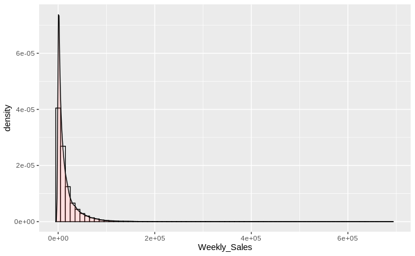

```r
ggplot(train, aes(x=Weekly_Sales)) +
  geom_histogram(aes(y=..density..),
                 binwidth=10000,
                 colour="black", fill="white") +
  geom_density(alpha=.2, fill="#FF6666")
```

### Visualize sales over time:

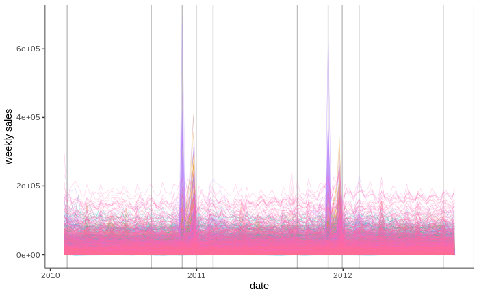

```r
ggplot(data = train,
       aes(x = Date,
           y = Weekly_Sales,
           group = Primary_Key,
           color = Primary_Key)
       ) +
  geom_vline(xintercept = unique(train$Date[train$IsHoliday]),
             color = 'gray') +
  geom_line(size = 0.2, alpha = 1/3) +
  xlab('date') +
  ylab('weekly sales') +
  theme(panel.border = element_rect(color="black", fill=NA, size=0.5),
        panel.grid.major = element_blank(),
        panel.grid.minor = element_blank(),
        panel.background = element_blank(),
        legend.position = 'None'
        )
```

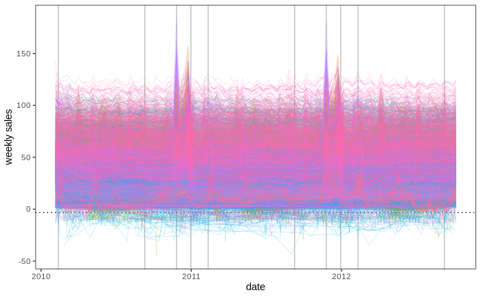

```r
ggplot(data = train,
       aes(x = Date,
           y = Weekly_Sales_boxcox,
           group = Primary_Key,
           color = Primary_Key)
       ) +
  geom_vline(xintercept = unique(train$Date[train$IsHoliday]),
             color = 'gray') +
  geom_hline(yintercept = -3.3, linetype = 'dotted') +
  geom_line(size = 0.2, alpha = 1/3) +
  xlab('date') +
  ylab('weekly sales') +
  theme(panel.border = element_rect(color="black", fill=NA, size=0.5),
        panel.grid.major = element_blank(),
        panel.grid.minor = element_blank(),
        panel.background = element_blank(),
        legend.position = 'None'
        )
```

It’s still messy, but we can now tell there are some negative sales in the data (w/lambda = 0.3, anything less than -3.3 is negative in the original scale). This has implications for forecast performance metrics like MAPE which can’t be computed on small/negative observations. We can break things down further by store and/or department to get a sense of how sales vary across these factors.

### Sales over time by store

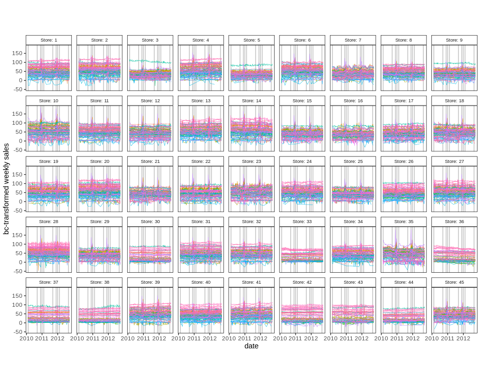

```r
ggplot(data = train,
       aes(x = Date,
           y = Weekly_Sales_boxcox,
           group = Primary_Key,
           color = Dept)
       ) +
  geom_vline(xintercept = unique(train$Date[train$IsHoliday]),
             color = 'gray') +
  geom_line(size = 0.2) +
  facet_wrap(~Store,
             nrow = 5,
             labeller = label_both) +
  xlab('date') +
  ylab('bc-transformed weekly sales') +
  theme(aspect.ratio = 1,
        panel.spacing.x = unit(0.5,"lines"),
        panel.spacing.y = unit(0.5,"lines"),
        panel.border = element_rect(color="black", fill=NA, size=0.5),
        panel.grid.major = element_blank(),
        panel.grid.minor = element_blank(),
        panel.background = element_blank(),
        strip.background = element_rect(color="black", fill="white"),
        strip.text.x = element_text(size = 7),
        legend.position = 'None'
        )
```

Here we can see there’s a mixture of sales patterns, and vertical offsets, across departments within each store. Some stores appear to lack the big “spiky” yearly seasonal pattern; although, this could be by chance. The dispersion of mean sells across departments apears to be somewhat similar from store to store.

### Sales over time by department

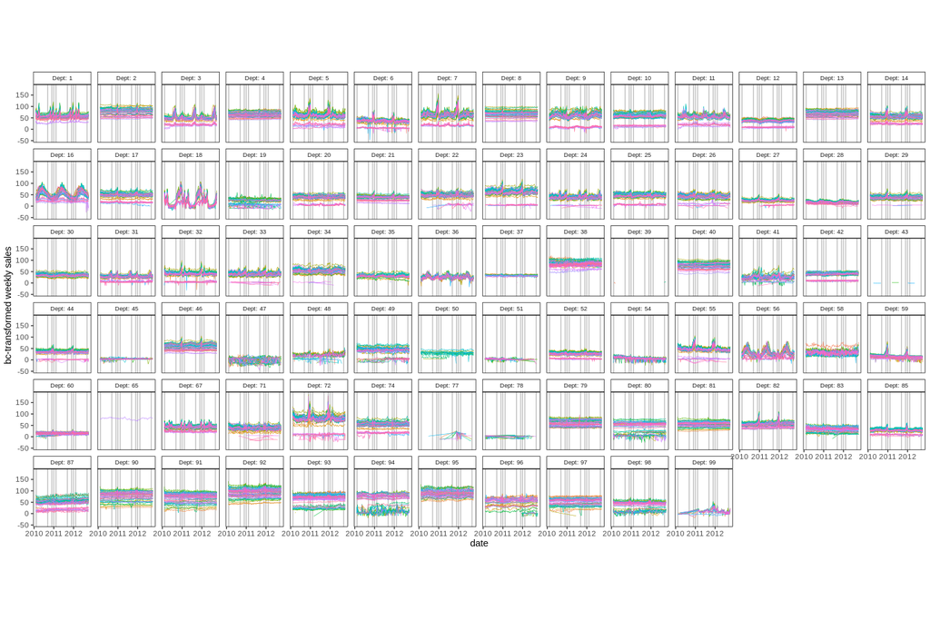

```r
ggplot(data = train,
       aes(x = Date,
           y = Weekly_Sales_boxcox,
           group = Primary_Key,
           color = Store)
       ) +
  geom_vline(xintercept = unique(train$Date[train$IsHoliday]),
             color = 'gray') +
  geom_line(size = 0.2) +
  facet_wrap(~Dept,
             nrow = 6,
             labeller = label_both) +
  xlab('date') +
  ylab('bc-transformed weekly sales') +
  theme(aspect.ratio = 1,
        panel.spacing.x = unit(0.5,"lines"),
        panel.spacing.y = unit(0.5,"lines"),
        panel.border = element_rect(color="black", fill=NA, size=0.5),
        panel.grid.major = element_blank(),
        panel.grid.minor = element_blank(),
        panel.background = element_blank(),
        strip.background = element_rect(color="black", fill="white"),
        strip.text.x = element_text(size = 7),
        legend.position = 'None'
        )
```

Here we can see that the sales pattern across stores within a department are pretty similar. For example, departments 87-92 are all pretty flat with some monthly seasonality, and 18 has a strong yearly seasonality. We can also see that the dispersion of mean sales across stores within each department varies across departments (i.e., some departments are more disperse than others; e.g., 37 vs 91). This suggests sales series could potentially be grouped by department to reduce forecast variance. There may also be “groups” that are defined across both stores and departments which could potentially be discovered in an unsupervise manner via clustering. We can also see that some departments-store pairings have either some missing data or are completely missing (e.g., 39, 43, 65, 77, 78, etc.). The series with lots of missing data may need to be treated differently.

### Missing data

314 of 3645 possible pairings are completely missing and we don’t really need to worry about these cases. Those with partially missing data are of more concern. How we address these cases depends on how much data is missing from each and whether the data is missing at random (i.e., not explained by holidays, etc.).

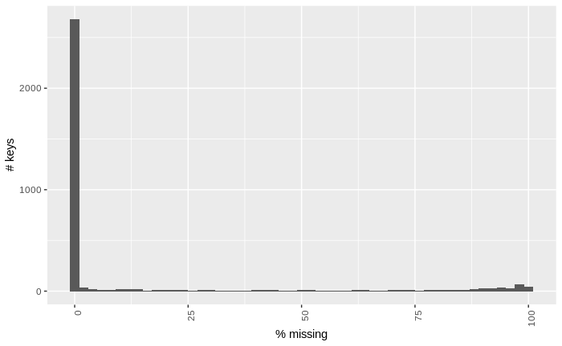

```r
dates_per_key <- length(unique(train$Date))
missing_by_key <- train %>%
  group_by(Primary_Key) %>%
  summarize(num_missing = (dates_per_key - n())/dates_per_key*100,
            .groups = 'drop') %>%
  collect

ggplot(data = missing_by_key, aes(x = num_missing)) +
  geom_histogram(binwidth = 2) +
  xlab('% missing') + ylab('# keys') +
  theme(axis.text.x = element_text(angle = 90, hjust = 1))
```

It looks like most keys (i.e., store-department pairs) are pretty good at regularly reporting data, but a portion are very bad. We should check to see if these keys come from a particular store or department.

## Missing data by store

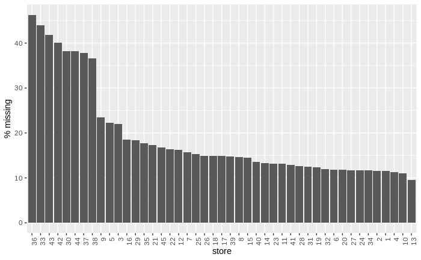

```r
dates_per_key <- length(unique(train$Date))
num_dept <- length(unique(train$Dept))
missing_by_store <- train %>%
  group_by(Store, ) %>%
  summarize(num_missing = (dates_per_key*num_dept - n())/(dates_per_key*num_dept)*100,
            .groups = 'drop') %>%
  arrange(desc(num_missing)) %>% collect

ggplot(data = missing_by_store, aes(x = reorder(Store, -num_missing), y = num_missing)) +
  geom_bar(stat = "identity") +
  xlab('store') + ylab('% missing') +
  theme(axis.text.x = element_text(angle = 90, hjust = 1))
```

There are some stores (i.e., the leftmost 8 above) report data less reliably; however, all stores have at least some department that fails to report some data. To determine if any of the stores are especially bad at reporting data, we could perform a permutation test by randomly shuffling store id’s across keys. This would let us know which stores we should press for data.

## Missing data by department

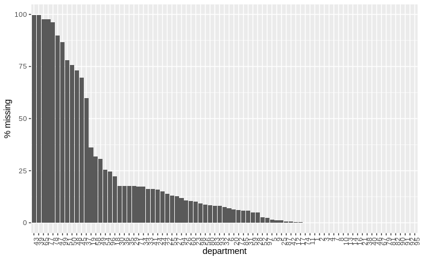

```r
dates_per_key <- length(unique(train$Date))
num_store <- length(unique(train$Store))
missing_by_dept <- train %>%
  group_by(Dept) %>%
  summarize(num_missing = (dates_per_key*num_store - n())/(dates_per_key*num_store)*100,
            .groups = 'drop') %>%
  arrange(desc(num_missing)) %>% collect

ggplot(data = missing_by_dept, aes(x = reorder(Dept, -num_missing), y = num_missing)) +
  geom_bar(stat = "identity") +
  xlab('department') + ylab('% missing') +
  theme(axis.text.x = element_text(angle = 90, hjust = 1))
```

Unlike the “missing-by-store” from the previous plot, this plot shows that there is a set of departments (i.e., the rightmost) that is very good about reporting data across all stores. Conversely, there are some departments (i.e., the leftmost) that hardly ever report data at any store. This is in agreement with the previous plot of “sales over time by department” and further suggests sales trends are highly dependent on department.

## Missing data by time

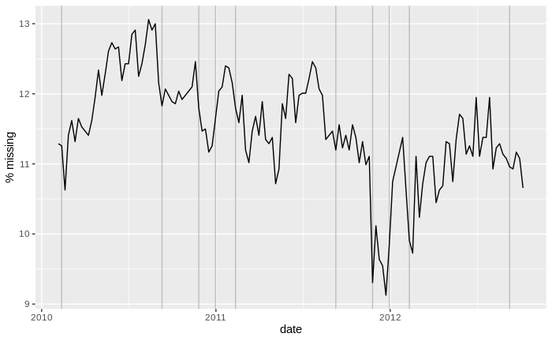

```r
keys_per_week <- length(unique(train$Primary_Key))

missing_by_dept <- train %>%
  group_by(Date) %>%
  summarize(num_missing = (keys_per_week - n())/(keys_per_week)*100,
            .groups = 'drop') %>%
  collect

ggplot(data = missing_by_dept,
       aes(
         x = Date,
         y = num_missing)
       ) +
  geom_vline(xintercept = unique(train$Date[train$IsHoliday]),
             color = 'gray') +
  geom_line() +
  xlab('date') + ylab('% missing')
```

It looks like stores may be better about reporting data between Thanksgiving and Christmas, and might get lazier after the New Year and during the Summer months, but it’s hard to say with confidence from this plot alone. We can get a rough sense of missing values are distributed within the series by looking at the distribution of difference between neighboring time points (i.e., distribution of delta_t).

### Distribution of missing gaps in data

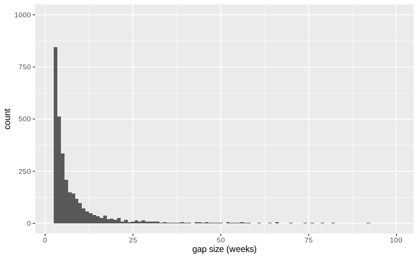

```r
delta_t <- data.frame('diff' = as.numeric(diff(train$Date))/7) %>%
  filter(!is.na(diff) & diff > 0)

ggplot(data = delta_t, aes(x = diff)) +
  geom_histogram(binwidth = 1) +
  xlab('gap size (weeks)') + ylab('count') + xlim(2, 100) +ylim(0, 1000)
```

### Baseline forecasts

As many of the series have lots of missing data, it is good to start with simple baseline forecasts that don’t require complete data. Mean, drift, naïve, and seasonal naïve models are good candidates here. Only mean and naïve models work with series having only one observation, as the drift model requires at least two observations and the seasonal naïve model requires an observation from the same week in one of the previous years.

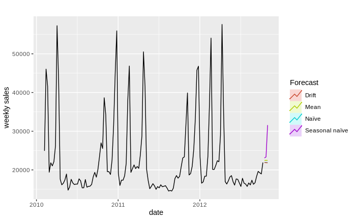

```r
# prepare data
key <- '1.1'
key_df <- train %>%
  get_key_df(key = key) %>%
  select(Date, Weekly_Sales)
key_ts <- ts(key_df$Weekly_Sales,
             freq = 52,
             start = lubridate::year(min(key_df$Date)) + lubridate::yday(min(key_df$Date))/365.25)

# run and plot forecasts
n <- sum(!is.na(key_ts))
if (n == 0){
  #nothing works without any data
  break
} else if (n == 1) {
  #only mean or naive work and both identical
  autoplot(key_ts) +
  autolayer(meanf(key_ts, h = 3), series="Mean", PI=FALSE) +
  autolayer(naive(key_ts, h = 3), series="Naïve", PI=FALSE) +
  xlab("date") + ylab("weekly sales") +
  guides(colour=guide_legend(title="Forecast"))
} else if (n > 1 & n < length(key_ts)) {
  #only mean, naive, and drift work
  autoplot(key_ts) +
  autolayer(meanf(key_ts, h = 3), series="Mean", PI=FALSE) +
  autolayer(naive(key_ts, h = 3), series="Naïve", PI=FALSE) +
  autolayer(rwf(key_ts, drift=TRUE, h=3), series="Drift", PI=FALSE) +
  xlab("date") + ylab("weekly sales") +
  guides(colour=guide_legend(title="Forecast"))
} else {
  #all work
  autoplot(key_ts) +
  autolayer(meanf(key_ts, h = 3), series="Mean", PI=FALSE) +
  autolayer(naive(key_ts, h = 3), series="Naïve", PI=FALSE) +
  autolayer(snaive(key_ts, h = 3), series="Seasonal naïve", PI=FALSE) +
  autolayer(rwf(key_ts, drift = TRUE, h = 3), series="Drift", PI=FALSE) +
  xlab("date") + ylab("weekly sales") +
  guides(colour=guide_legend(title="Forecast"))
}
```

### Prophet forecast

Facebook’s Prophet is a popular GAM-based approach that is able to simultaneously handle trends, complex seasonality, holidays, and some missing data. It is therefore a good candidate for many/most of the series in this dataset.

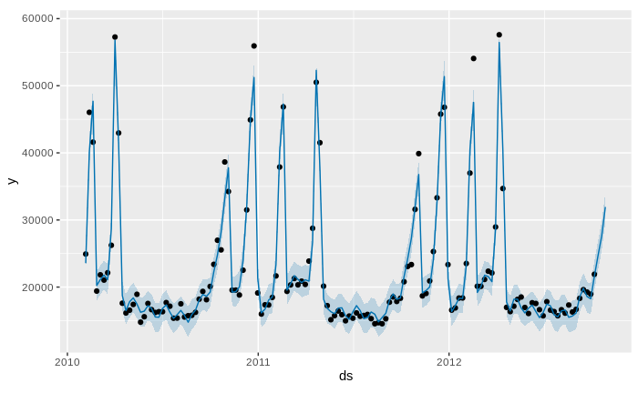

```r
#get key df
key <- '1.1'
key_df <- train %>%
  get_key_df(key = key, add_na = FALSE) %>%
  rename(ds = Date) %>%
  rename(y = Weekly_Sales)

#get holidays into prophet format
holiday_df <- get_holiday_df(train,
                             test,
                             holidays = c('Christmas',
                                          'Thanksgiving',
                                          'LaborDay',
                                          'SuperBowl',
                                          'Easter'),
                             lower_window = -14,
                             upper_window = 14)

#prepare model
prophet_model <- prophet(growth = 'linear',
                         yearly.seasonality = 6,
                         weekly.seasonality = FALSE,
                         daily.seasonality = FALSE,
                         seasonality.mode = "multiplicative",
                         holidays = holiday_df,
                         seasonality.prior.scale = 10,
                         holidays.prior.scale = 10,
                         changepoint.prior.scale = 0.05,
                         n.changepoints = 25,
                         fit = FALSE)

#add monthly seasonality
prophet_model <- add_seasonality(prophet_model, name='monthly', period=30.5, fourier.order=1)

#fit model
prophet_model <- fit.prophet(prophet_model, df = key_df)

#get forecast
future <- make_future_dataframe(prophet_model,
                                periods = 3,
                                freq = 'week')
forecast <- predict(prophet_model, future)

#plot results
plot(prophet_model, forecast)
```

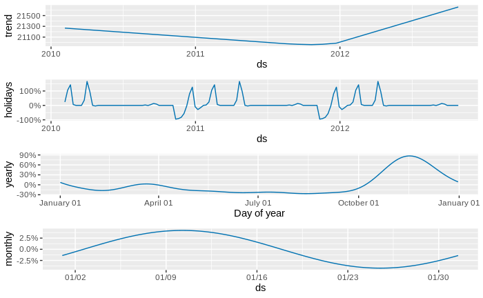

```r
prophet_plot_components(prophet_model, forecast)
```

A nice thing about Prohet is it’s ability to autodetect the number of observations and enable/disable the yeary seasonality terms accordingly. It also makes it easy to include leading/lagging terms for each of the holidays. However, handling monthly seasonality is a slightly challenging. Even though it is is able to partially capture monthly seasonality either via yearly seasonality, or by adding a seasonality with a custom period, the monthly period is assumed to be constant in these cases (i.e., ~30.5 days). In our case, it might be nice to have the option of fitting a periodic function to a ‘week_of_month’ term (e.g., by using cyclical bases as in mgcv). It’s also unclear how Prophet handles indentifiability constraints (e.g., all terms should sum to zero across the observations).

### QGAM Forecast

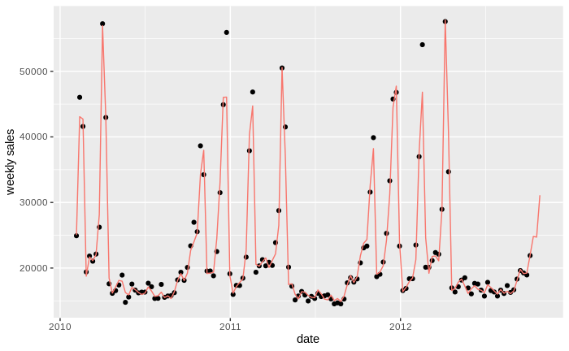

```r
#get key df
key <- '1.1'
key_df <- train %>%
  get_key_df(key = key, add_na = FALSE)

#fit model
qgam_model <- qgam(Weekly_Sales ~ WeekOfEaster +
                     OneWeekBeforeEaster + TwoWeeksBeforeEaster +
                     TwoWeeksBeforeThanksgiving + OneWeekBeforeThanksgiving +
                     WeekOfThanksgiving +
                     s(DaysFromStart, bs = "gp", k=45) +
                     s(DayYearNormalized, bs = "ad", k=52) +
                     s(DayMonthNormalized, bs = "cp"),
                   qu = 0.5,
                   control = list(progress = FALSE),
                   data = key_df)

#get forecast
new_df <- rbind(train, test) %>%
  get_key_df(key = '1.1', add_na = FALSE)
forecast <- predict(object = qgam_model,
                    newdata = new_df,
                    type = "response")

#plot results
ggplot(data = key_df, aes(x = Date, y = Weekly_Sales)) +
  geom_point() +
  geom_line(data = new_df,
            mapping = aes(x = Date,
                          y = forecast,
                          color = '#619CFF')) +
  xlab('date') + ylab('weekly sales') +
  theme(legend.position = 'None')
```

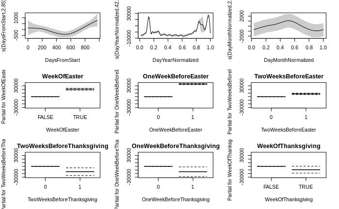

```r
plot(qgam_model, pages = 1, scale = 0, scheme = 1, rug = FALSE, all.terms = TRUE)
```

### Cross-validate all models

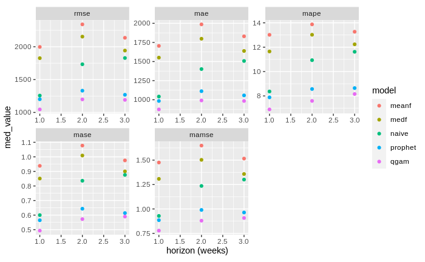

```r
# # create nested data frame of full training data by key
# train_by_key <- nest_by_key(train)
#
# # create holidays argument
# holiday_df <- get_holiday_df(train,
#                              test,
#                              holidays = c('Christmas',
#                                           'Thanksgiving',
#                                           'LaborDay',
#                                           'SuperBowl',
#                                           'Easter'),
#                              lower_window = -14,
#                              upper_window = 14)
#
# # create cutoff dates argument
# num_dates <- 5
# cutoff_dates <- as.Date(c("2012-09-14")) - 21*seq(0, num_dates - 1)
#
# #cross-validate by key in parallel
# num_cores <- detectCores() - 1
# cl <- makeCluster(num_cores, type="FORK", outfile="")
# registerDoParallel(cl)
# train_by_key$errors <- foreach(i = 1:nrow(train_by_key)) %dopar%
#   ts_cv(data = train_by_key$data[[i]],
#         cutoff_dates = cutoff_dates,
#         holidays = holiday_df,
#         fit_qgam = TRUE)
# stopCluster(cl)
#
# # gather performance metrics
# train_by_key$metrics <- foreach(i = 1:nrow(train_by_key)) %do%
#     gather_metrics(error_df = train_by_key$errors[[i]])

#start here to avoid retraining above
if (!exists('train_by_key')){
  train_by_key <- readRDS('/home/brian/R/salesforecast/data/train_by_key_qgam')
}

# filter out problematic keys and compute summaries for each model, metric and horizon
metric_df <- train_by_key %>%
  filter(!is.na(metrics)) %>%
  mutate(num_obs = map(data, num_obs),
         min_sales = map(data, min_sales)) %>%
  filter(num_obs > 50 & min_sales > 1000) %>%
  select(Primary_Key, metrics) %>%
  unnest(metrics) %>%
  group_by(model, horizon, metric) %>%
  summarise(med_value = median(value[!is.infinite(value)], na.rm = TRUE),
            mean_value = mean(value[!is.infinite(value)], na.rm = TRUE),
            .groups = 'drop')
metric_df$metric <- factor(metric_df$metric, ordered = TRUE, levels = c('rmse', 'mae', 'mape', 'mase', 'mamse'))

#plot performace metrics
ggplot(data = metric_df, aes(x = horizon, y = med_value, group = model, color = model)) +
  geom_point() +
  facet_wrap(~metric, scales = "free", nrow = 2) +
  xlab('horizon (weeks)') +
  theme(aspect.ratio = 1)
```

### Error distributions

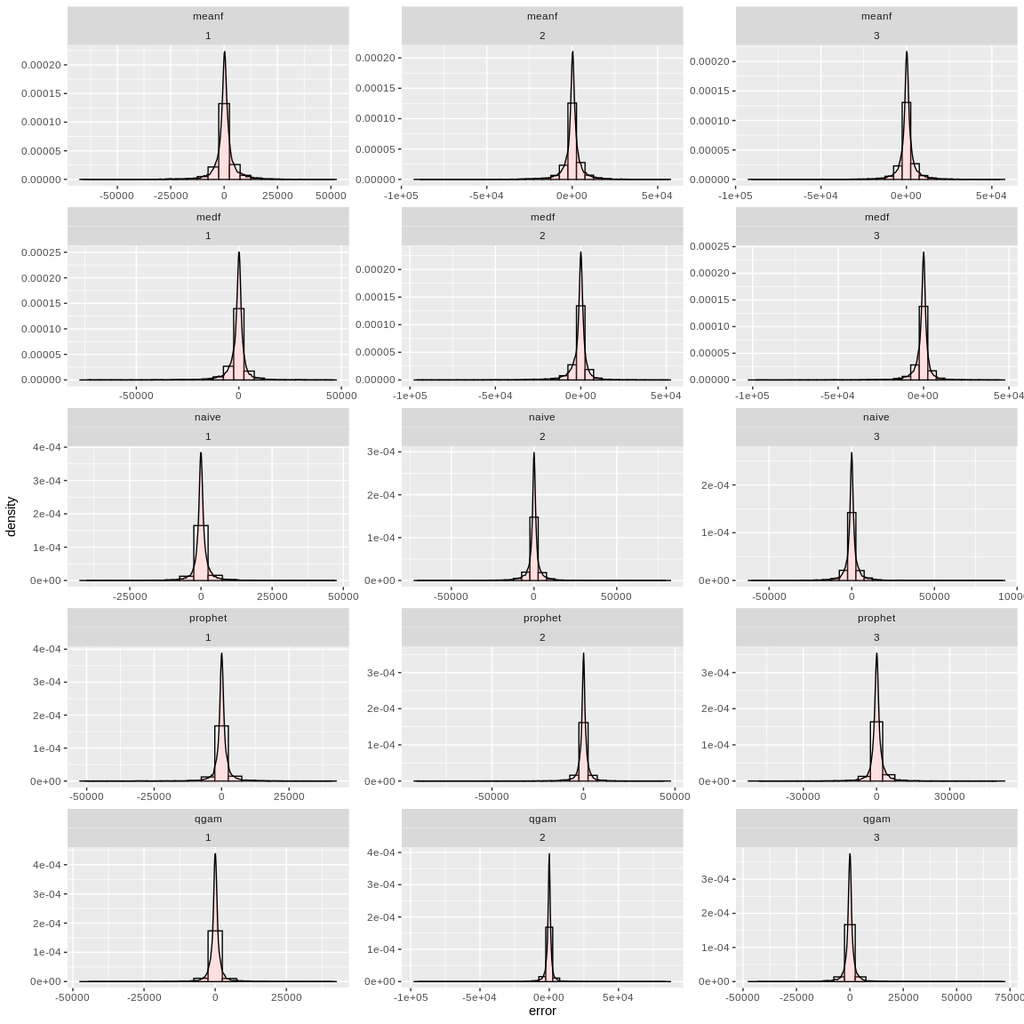

```r
# gather errors
error_df <- train_by_key %>%
  filter(!is.na(errors)) %>%
  mutate(num_obs = map(data, num_obs),
         min_sales = map(data, min_sales)) %>%
  filter(num_obs > 100,
         min_sales > 1000) %>%
  select(Primary_Key, errors) %>%
  unnest(errors) %>%
  mutate(percent_error = 100*error/obs,
         scaled_error = error/mean_diff,
         med_scaled_error = error/med_diff)

# plot error distributions by model and horizon
ggplot(error_df, aes(x=error)) +
  geom_histogram(aes(y=..density..),      # Histogram with density instead of count on y-axis
                 binwidth=5000,
                 colour="black", fill="white") +
  geom_density(alpha=.2, fill="#FF6666") +
  facet_wrap(model~horizon, scales = 'free', nrow = 5)
```

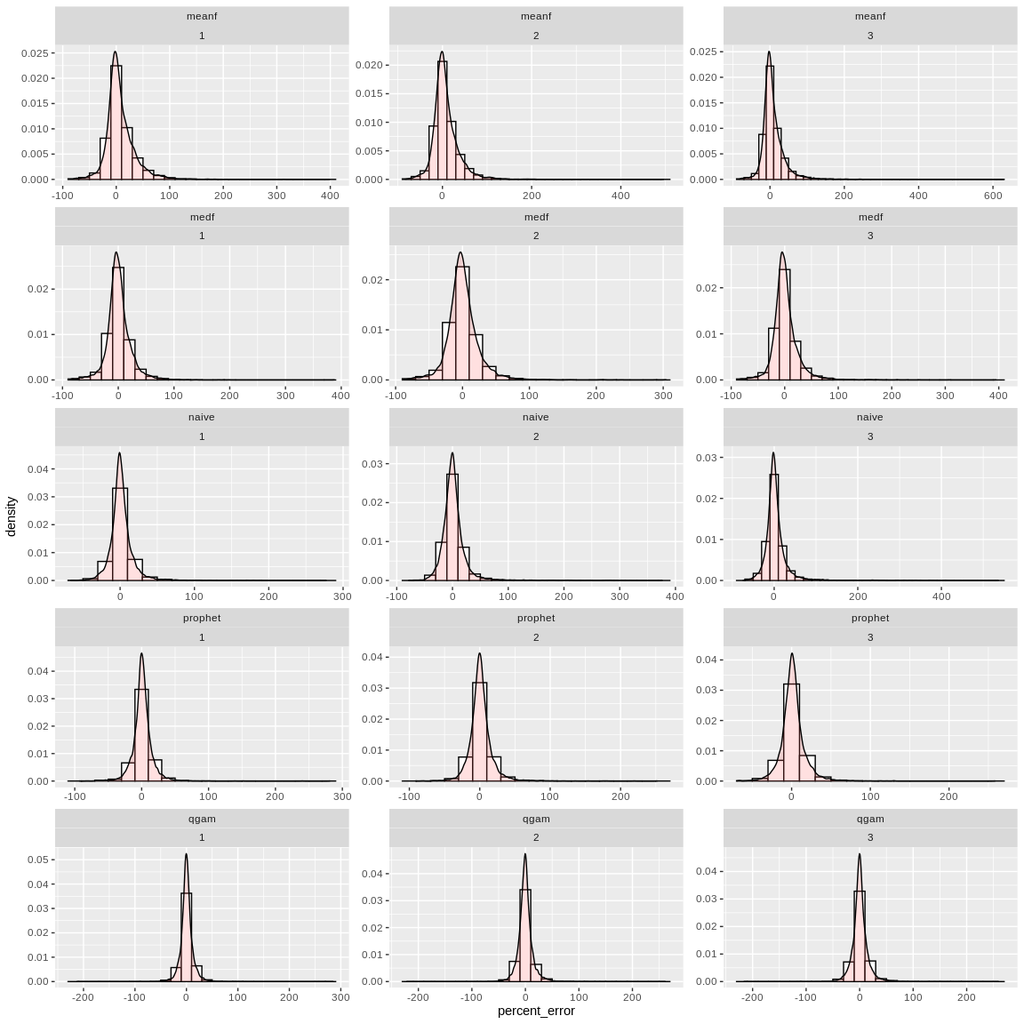

```r
# plot percent error distributions by model and horizon
ggplot(error_df, aes(x=percent_error)) +
  geom_histogram(aes(y=..density..),      # Histogram with density instead of count on y-axis
                 binwidth=20,
                 colour="black", fill="white") +
  geom_density(alpha=.2, fill="#FF6666") +
  facet_wrap(model~horizon, scales = 'free', nrow = 5)
```

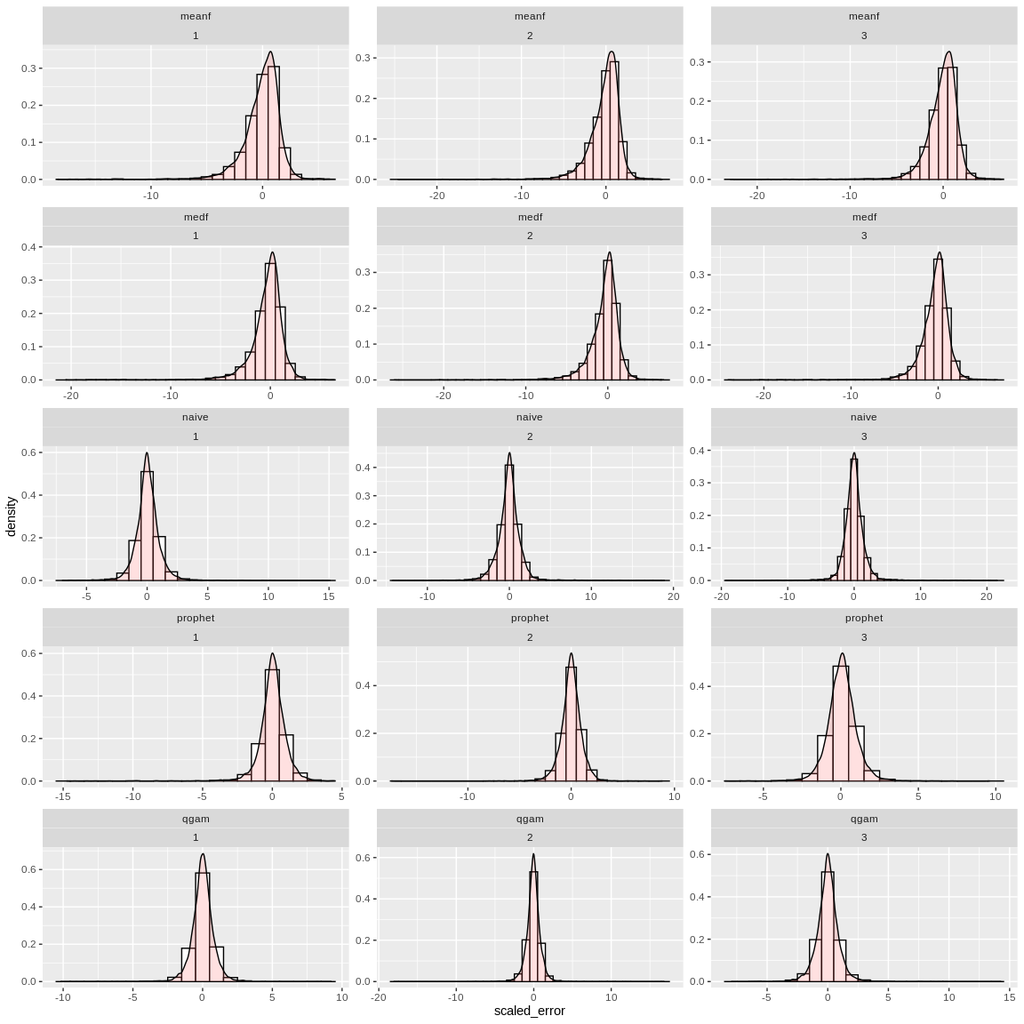

```r
# plot scaled error distributions by model and horizon
ggplot(error_df, aes(x=scaled_error)) +
  geom_histogram(aes(y=..density..),      # Histogram with density instead of count on y-axis
                 binwidth=1,
                 colour="black", fill="white") +
  geom_density(alpha=.2, fill="#FF6666") +
  facet_wrap(model~horizon, scales = 'free', nrow = 5)
```

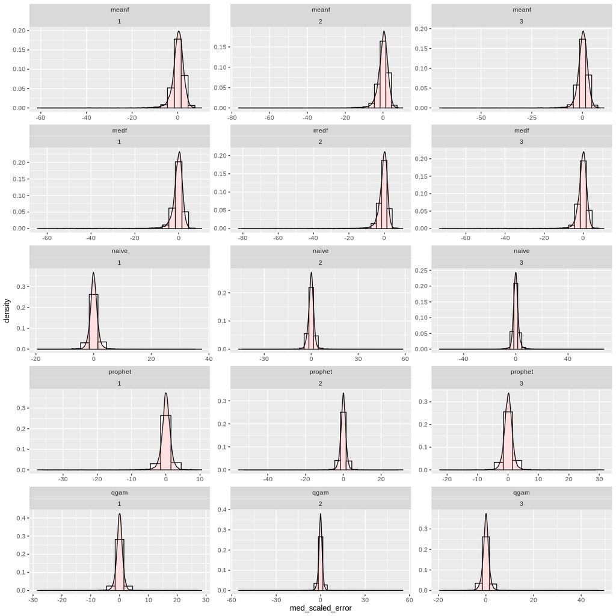

```r
# plot median scaled error distributions by model and horizon
ggplot(error_df, aes(x=med_scaled_error)) +
  geom_histogram(aes(y=..density..),      # Histogram with density instead of count on y-axis
                 binwidth=3,
                 colour="black", fill="white") +
  geom_density(alpha=.2, fill="#FF6666") +
  facet_wrap(model~horizon, scales = 'free', nrow = 5)
```

## List keys with largest errors

```r
if (!exists('train_by_key')){
  train_by_key <- readRDS('/home/brian/R/salesforecast/data/train_by_key')
}
train_by_key %>%
  filter(!is.na(errors)) %>%
  mutate(num_obs = map(data, num_obs),
         min_sales = map(data, min_sales)) %>%
  select(Primary_Key, errors, num_obs, min_sales) %>%
  unnest(c(errors, num_obs, min_sales)) %>%
  filter(model == 'prophet',
         num_obs > 100) %>%
  mutate(scaled_error = abs(error/mean_diff)) %>%
  arrange(desc(scaled_error))
```

| Primary_Key | error | obs | mean_diff | med_diff | horizon | model | num_obs | min_sales | scaled_error |
| --- | --- | --- | --- | --- | --- | --- | --- | --- | --- |
| 42.31 | -1047.98527 | 1063.94 | 43.47347 | 24.000 | 2 | prophet | 126 | -23.00 | 24.106320 |
| 13.3 | -91225.79179 | 114230.60 | 5242.79609 | 1733.530 | 2 | prophet | 140 | 13926.67 | 17.400217 |
| 33.3 | -1174.35422 | 2097.40 | 71.56977 | 34.045 | 1 | prophet | 140 | 10.80 | 16.408523 |
| 33.3 | -928.96414 | 1252.96 | 58.76685 | 33.885 | 3 | prophet | 140 | 10.80 | 15.807621 |
| 43.3 | -3130.57239 | 5023.27 | 207.01685 | 103.000 | 3 | prophet | 140 | 377.40 | 15.122307 |
| 42.7 | -3458.47891 | 4705.49 | 232.92669 | 108.835 | 2 | prophet | 140 | 167.67 | 14.847929 |
| 9.3 | -22925.35379 | 34274.30 | 1554.39489 | 636.380 | 1 | prophet | 140 | 3844.22 | 14.748732 |
| 5.3 | -11864.10840 | 16381.04 | 837.55353 | 360.330 | 1 | prophet | 140 | 2198.92 | 14.165194 |
| 31.3 | -30771.68134 | 46168.87 | 2313.48173 | 858.080 | 1 | prophet | 140 | 5609.87 | 13.301026 |
| 1.3 | -30379.62517 | 50701.30 | 2392.94962 | 952.490 | 1 | prophet | 140 | 6165.73 | 12.695472 |

[output cut: 990 more lines]

## Final test

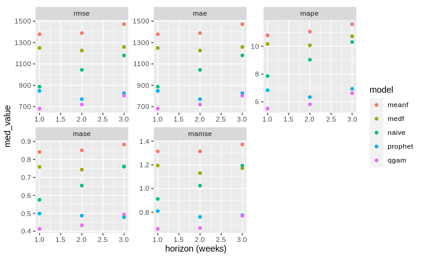

```r
# # create nested data frame of full training data by key
# if (exists('train$Weekly_Sales_boxcox')){
#  train <- train %>% select(!Weekly_Sales_boxcox)
# }
# test_by_key <- nest_by_key(rbind(train, test))
#
# # create holidays argument
# holiday_df <- get_holiday_df(train,
#                              test,
#                              holidays = c('Christmas',
#                                           'Thanksgiving',
#                                           'LaborDay',
#                                           'SuperBowl',
#                                           'Easter'),
#                              lower_window = -14,
#                              upper_window = 14)
#
# #cutoff date should just be last date of train
# cutoff_date <- max(train$Date)
#
# #test by key
# num_cores <- detectCores() - 1
# cl <- makeCluster(num_cores, type="FORK", outfile="")
# registerDoParallel(cl)
# test_by_key$errors <- foreach(i = 1:nrow(test_by_key)) %dopar%
#   ts_cv(data = test_by_key$data[[i]],
#         cutoff_dates = cutoff_date,
#         holidays = holiday_df,
#         fit_qgam = TRUE)
# stopCluster(cl)
#
# # gather performance metrics
# test_by_key$metrics <- foreach(i = 1:nrow(test_by_key)) %do%
#     gather_metrics(error_df = test_by_key$errors[[i]])

if (!exists('test_by_key')){
  test_by_key <- readRDS('/home/brian/R/salesforecast/data/test_by_key')
}

# filter out problematic keys and compute summaries for each model, metric and horizon
metric_df <- test_by_key %>%
  filter(!is.na(metrics)) %>%
  mutate(num_obs = map(data, num_obs),
         min_sales = map(data, min_sales)) %>%
  filter(num_obs > 50 & min_sales > 1000) %>%
  select(Primary_Key, metrics) %>%
  unnest(metrics) %>%
  group_by(model, horizon, metric) %>%
  summarise(med_value = median(value[!is.infinite(value)], na.rm = TRUE),
            mean_value = mean(value[!is.infinite(value)], na.rm = TRUE),
            .groups = 'drop')
metric_df$metric <- factor(metric_df$metric,
                           ordered = TRUE,
                           levels = c('rmse', 'mae', 'mape', 'mase', 'mamse'))

#plot performace metrics
ggplot(data = metric_df, aes(x = horizon, y = med_value, group = model, color = model)) +
  geom_point() +
  facet_wrap(~metric, scales = "free", nrow = 2) +
  xlab('horizon (weeks)') +
  theme(aspect.ratio = 1)
```

Perhaps unsuprisingly, QGAM and Prophet are the best performing models. Further improvements could likely be made by incorporating autoregressive terms or additional covariance structure to the extrapolated predictions.